# REMOTE SENSING DATA ANALYSIS USING R

### Image Processing and Analysis

Many image processing and analysis techniques have been developed to aid the interpretation of remote sensing images and to extract as much information as possible from the images. The choice of specific techniques or algorithms to use depends on the goals of each individual project.

### Satellite information:

The Moderate Resolution Imaging Spectroradiometer (MODIS) is a payload imaging sensor built by Santa Barbara Remote Sensing that was launched into Earth orbit by NASA in 1999 on board the Terra (EOS AM) Satellite, and in 2002 on board the Aqua (EOS PM) satellite. The MODIS sensor has 36 spectral bands, seven of which are designed for the study of vegetation and land surfaces: blue (459–479 nm), green (545–565 nm), red (620–670 nm), near infrared (NIR1: 841–875 nm; NIR2: 1230–1250 nm), and shortwave infrared (SWIR1: 1628– 1652 nm, SWIR2: 2105–2155 nm).

#### Application:

With its low spatial resolution but high temporal resolution, MODIS data is useful to track changes in the landscape over time. Examples of such applications are the monitoring of vegetation health by means of time-series analyses with vegetation indices, long term land cover changes (e.g. to monitor deforestation rates), flooding of water from pluvial(period marked by increased rainfall) at riverine, or sea level rise flooding in coastal areas.

## Normalized difference vegetation index (NDVI)

The normalized difference vegetation index (NDVI) is a simple graphical indicator that can be used to analyze remote sensing measurements, from a space platform, and assess whether the target being observed contains **live green vegetation or not**.It is calculated by the following formula:  
$NDVI=\frac{(Xnir-Xred)}{(Xnir+Xred)}$

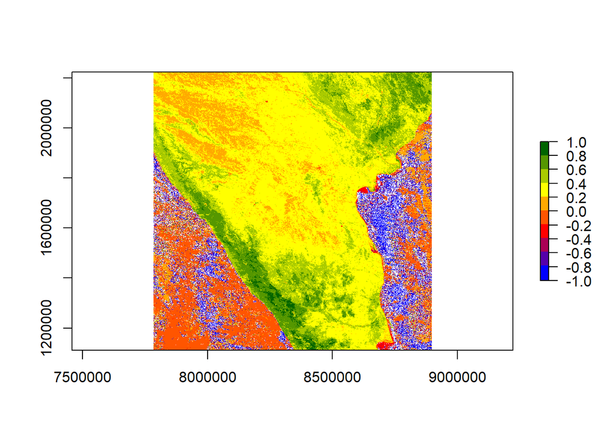

Values description: The value range of an NDVI is -1 to 1. Negative values of NDVI (values approaching -1) correspond to water. Values close to zero (-0.1 to 0.1) generally correspond to barren areas of rock, sand, or snow. Low, positive values represent shrub and grassland (approximately 0.2 to 0.4), while high values indicate temperate and tropical rainforests (values approaching 1).

## VEGETATION COVER (from NDVI)

Pixels having NDVI values greater than 0.4 are definitely vegetation. Following operation masks all nonvegetation pixels and diaplays only vegetation which is observed from NDVI.

```r
VEGCOVER<-calc(NDVI,function(x){x[x< 0.4]<- NA;return(x)})
```

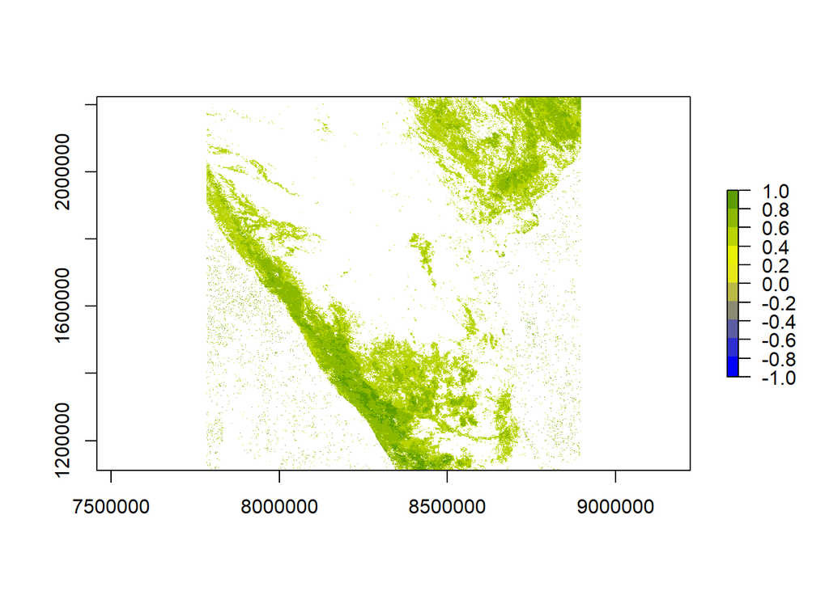

## Enhanced vegetation index (EVI)

The enhanced vegetation index (EVI) is an ‘optimized’ vegetation index designed to enhance the vegetation signal with improved sensitivity in high biomass regions and improved vegetation monitoring through a de-coupling of the canopy background signal and a reduction in atmosphere influences.

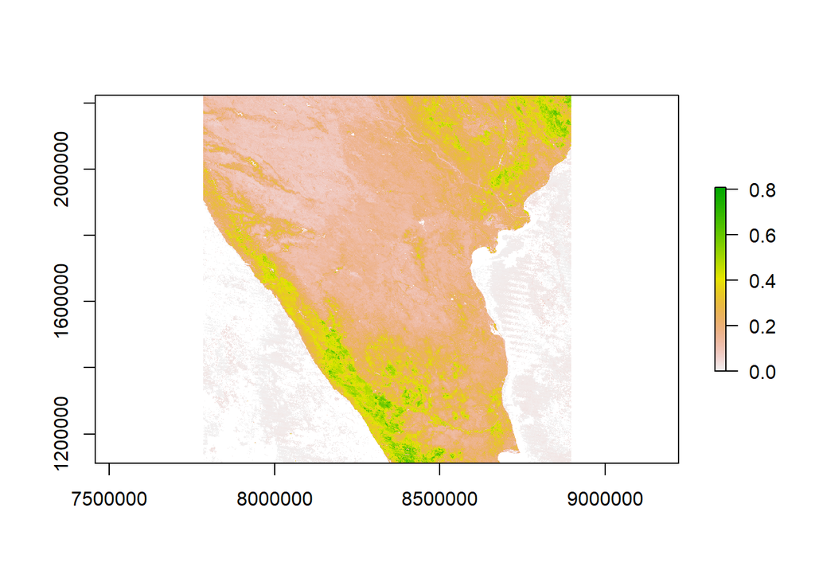

$EVI=\frac{G \times (NIR-RED)}{(NIR+C1 \times RED-C2 \times Blue+L)}$  
The coefficients adopted in the MODIS-EVI algorithm are; L=1, C1 = 6, C2 = 7.5, and G (gain factor) = 2.5 .  
Values description: The value range of an EVI is 0 to 1, where healthy vegetation generally falls between values of 0.20 to 0.80.

## Normalized difference Water index (NDWI)

### 1.Water content of leaves.

It is used to monitor changes in water content of leaves, using near-infrared (NIR) and short-wave infrared (SWIR) wavelengths, proposed by Gao in 1996:

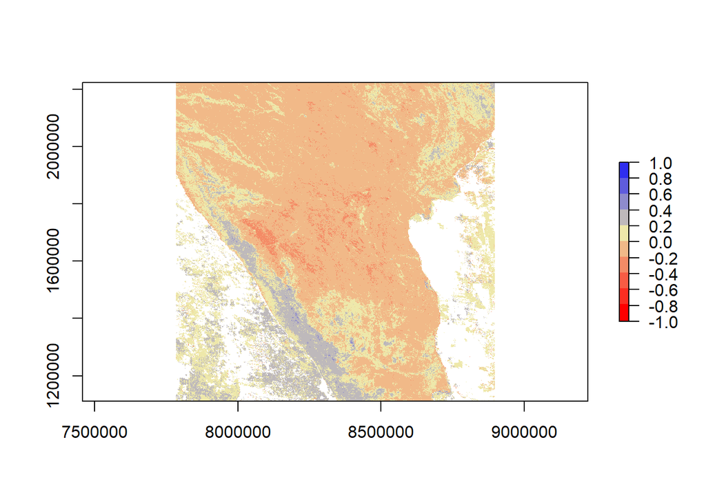

$NDWI= \frac{(Xnir-Xswir)}{(Xnir+Xswir)}$  
Values description: The value range of an NDWI is -1 to 1.  
-1 to 0 - Bright surface with no vegetation or water content.  
+1 - represent water content.

#### 2.Water content in water bodies.

It is used to monitor changes related to water content in water bodies, using green and NIR wavelengths, defined by McFeeters (1996):  
$NDWI=\frac{(Xgreen-Xnir)}{(Xgreen+Xnir)}$

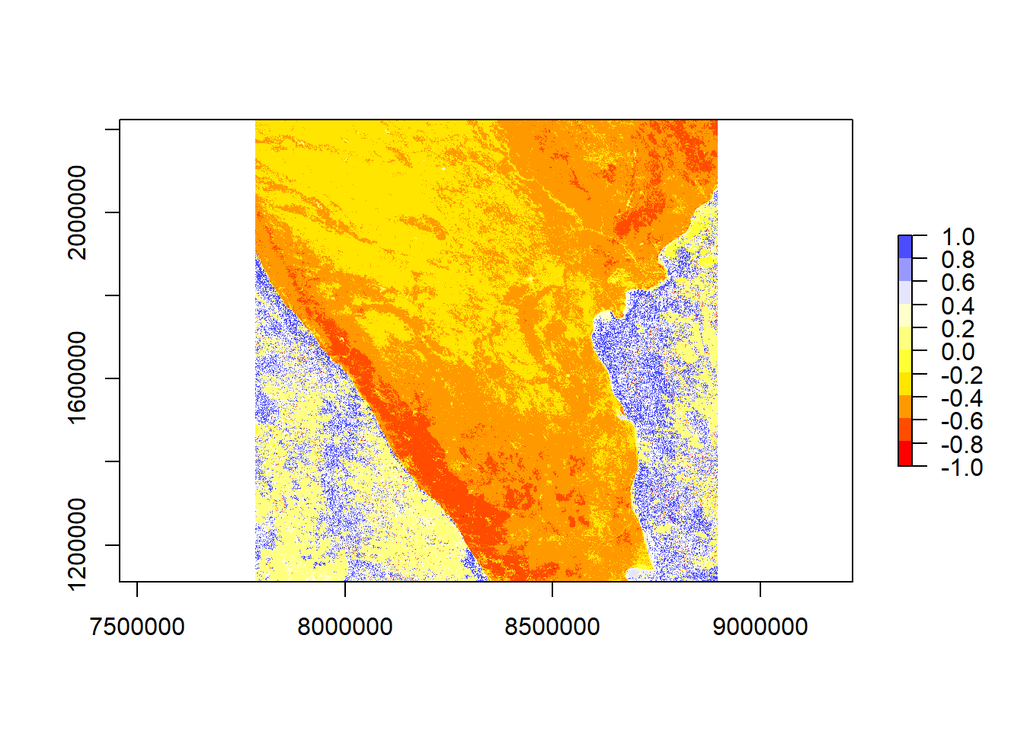

Values description:  
< 0.3 - Non-water  
>= 0.3 - Water.